# Basic exploratory analysis

Camilo A. Ordóñez-Pinilla camilo.ordonez@gmail.com

09/28/2020

### **Project ‘Propuesta de comunicación pública basada en el análisis de la motivación para la adopción de las conductas de prevención en el contexto del COVID-19’**

### Github Link

RMarkdown code that generates this notebook is available to project members at [github](https://github.com/caordonezp/project_ascofapsi_2020)

## Preliminars

As usual, we start setting up the working directory

```r
setwd ("E:/OTHER ACADEMICS/PROYECTOS COVID 19/PROYECTOS DATOS ASCOFAPSI/project_ascofapsi_2020")
```

Loading the required packages

```r
pacman::p_load(tidyverse, dplyr, summarytools, ggplot2, readxl, corrplot, knitr)
```

and uploading the data base in a new data frame called ‘ascofapsi’

```r
ascofapsi <- read_excel("base de datos limpia.xlsx")
```

## Descriptive summary

```r
print(dfSummary(ascofapsi, graph.magnif = 0.75), method = 'render')
```

Data Frame Summary

ascofapsi

**Dimensions**: 926 x 118  
**Duplicates**: 0

| **No** | **Variable** | **Stats / Values** | **Freqs (% of Valid)** | **Graph** | **Valid** | **Missing** |
| --- | --- | --- | --- | --- | --- | --- |
| 1 | mtemporal [POSIXct, POSIXt] | min : 2020-05-21 17:50:00 med : 2020-05-28 23:55:27 max : 2020-06-11 06:22:03 range : 20d 12H 32M 2.76S | 926 distinct values |  | 926 (100%) | 0 (0%) |
| 2 | consentimiento [character] | 1. Soy mayor de 18 años y ac | 926 ( 100.0% ) |  | 926 (100%) | 0 (0%) |
| 3 | c_actifisica [numeric] | Mean (sd) : -0.4 (1.3) min < med < max: -2 < -1 < 2 IQR (CV) : 1 (-3.1) | -2 : 209 ( 22.6% ) -1 : 275 ( 29.7% ) 0 : 220 ( 23.8% ) 1 : 129 ( 13.9% ) 2 : 93 ( 10.0% ) |  | 926 (100%) | 0 (0%) |
| 4 | c_habisueno [numeric] | Mean (sd) : -0.5 (1.1) min < med < max: -2 < -1 < 2 IQR (CV) : 1 (-2.2) | -2 : 166 ( 17.9% ) -1 : 325 ( 35.1% ) 0 : 272 ( 29.4% ) 1 : 117 ( 12.6% ) 2 : 46 ( 5.0% ) |  | 926 (100%) | 0 (0%) |
| 5 | c_alimentacion [numeric] | Mean (sd) : 0.1 (1.1) min < med < max: -2 < 0 < 2 IQR (CV) : 2 (8.7) | -2 : 68 ( 7.3% ) -1 : 213 ( 23.0% ) 0 : 299 ( 32.3% ) 1 : 222 ( 24.0% ) 2 : 124 ( 13.4% ) |  | 926 (100%) | 0 (0%) |
| 6 | c_ingresoeconomico [numeric] | Mean (sd) : -0.7 (1) min < med < max: -2 < -1 < 2 IQR (CV) : 2 (-1.3) | -2 : 256 ( 27.7% ) -1 : 244 ( 26.4% ) 0 : 372 ( 40.2% ) 1 : 40 ( 4.3% ) 2 : 14 ( 1.5% ) |  | 926 (100%) | 0 (0%) |
| 7 | c_actilaboral [numeric] | Mean (sd) : -0.9 (1) min < med < max: -2 < -1 < 2 IQR (CV) : 2 (-1.1) | -2 : 294 ( 31.8% ) -1 : 327 ( 35.3% ) 0 : 243 ( 26.2% ) 1 : 45 ( 4.9% ) 2 : 17 ( 1.8% ) |  | 926 (100%) | 0 (0%) |
| 8 | c_rel_parejafamilia [numeric] | Mean (sd) : 0.2 (1.1) min < med < max: -2 < 0 < 2 IQR (CV) : 1 (4.4) | -2 : 48 ( 5.2% ) -1 : 169 ( 18.2% ) 0 : 343 ( 37.0% ) 1 : 246 ( 26.6% ) 2 : 120 ( 13.0% ) |  | 926 (100%) | 0 (0%) |
| 9 | c_rel_vecinos [numeric] | Mean (sd) : 0 (0.7) min < med < max: -2 < 0 < 2 IQR (CV) : 0 (21.4) | -2 : 29 ( 3.1% ) -1 : 72 ( 7.8% ) 0 : 701 ( 75.7% ) 1 : 89 ( 9.6% ) 2 : 35 ( 3.8% ) |  | 926 (100%) | 0 (0%) |
| 10 | c_rel_amigosyconocidos [numeric] | Mean (sd) : -0.1 (0.9) min < med < max: -2 < 0 < 2 IQR (CV) : 1 (-13.2) | -2 : 44 ( 4.8% ) -1 : 218 ( 23.5% ) 0 : 466 ( 50.3% ) 1 : 152 ( 16.4% ) 2 : 46 ( 5.0% ) |  | 926 (100%) | 0 (0%) |
| 11 | c_pasatiempos [numeric] | Mean (sd) : 0.5 (1.1) min < med < max: -2 < 1 < 2 IQR (CV) : 1 (2.4) | -2 : 58 ( 6.3% ) -1 : 124 ( 13.4% ) 0 : 234 ( 25.3% ) 1 : 339 ( 36.6% ) 2 : 171 ( 18.5% ) |  | 926 (100%) | 0 (0%) |
| 12 | adap_restriccionmovilidad [numeric] | Mean (sd) : 0.7 (0.9) min < med < max: -2 < 1 < 2 IQR (CV) : 1 (1.3) | -2 : 18 ( 1.9% ) -1 : 82 ( 8.9% ) 0 : 229 ( 24.7% ) 1 : 428 ( 46.2% ) 2 : 169 ( 18.2% ) |  | 926 (100%) | 0 (0%) |
| 13 | t_aguante [numeric] | Mean (sd) : 2.9 (0.9) min < med < max: 0 < 3 < 4 IQR (CV) : 2 (0.3) | 0 : 15 ( 1.6% ) 1 : 54 ( 5.8% ) 2 : 202 ( 21.8% ) 3 : 415 ( 44.8% ) 4 : 240 ( 25.9% ) |  | 926 (100%) | 0 (0%) |
| 14 | r_usotapabocas [numeric] | Mean (sd) : 2.2 (0.8) min < med < max: 0 < 2 < 3 IQR (CV) : 1 (0.4) | 0 : 22 ( 2.4% ) 1 : 179 ( 19.3% ) 2 : 308 ( 33.3% ) 3 : 417 ( 45.0% ) |  | 926 (100%) | 0 (0%) |
| 15 | r_usoguantes [numeric] | Mean (sd) : 1.1 (1) min < med < max: 0 < 1 < 3 IQR (CV) : 2 (0.9) | 0 : 324 ( 35.0% ) 1 : 306 ( 33.1% ) 2 : 160 ( 17.3% ) 3 : 136 ( 14.7% ) |  | 926 (100%) | 0 (0%) |
| 16 | r_lavadomanos [numeric] | Mean (sd) : 2.1 (0.8) min < med < max: 0 < 2 < 3 IQR (CV) : 1 (0.4) | 0 : 17 ( 1.8% ) 1 : 171 ( 18.5% ) 2 : 408 ( 44.1% ) 3 : 330 ( 35.6% ) |  | 926 (100%) | 0 (0%) |
| 17 | r_evitocara [numeric] | Mean (sd) : 1.8 (0.8) min < med < max: 0 < 2 < 3 IQR (CV) : 1 (0.5) | 0 : 57 ( 6.2% ) 1 : 275 ( 29.7% ) 2 : 392 ( 42.3% ) 3 : 202 ( 21.8% ) |  | 926 (100%) | 0 (0%) |
| 18 | r_acor_lavarmanos [numeric] | Mean (sd) : 2.2 (0.8) min < med < max: 0 < 2 < 3 IQR (CV) : 1 (0.3) | 0 : 12 ( 1.3% ) 1 : 153 ( 16.5% ) 2 : 403 ( 43.5% ) 3 : 358 ( 38.7% ) |  | 926 (100%) | 0 (0%) |
| 19 | r_acor_mantenerdistancia [numeric] | Mean (sd) : 2.4 (0.7) min < med < max: 0 < 3 < 3 IQR (CV) : 1 (0.3) | 0 : 14 ( 1.5% ) 1 : 69 ( 7.4% ) 2 : 344 ( 37.1% ) 3 : 499 ( 53.9% ) |  | 926 (100%) | 0 (0%) |
| 20 | r_salirdecasa [numeric] | Mean (sd) : 2.3 (0.8) min < med < max: 0 < 3 < 3 IQR (CV) : 1 (0.4) | 0 : 32 ( 3.5% ) 1 : 115 ( 12.4% ) 2 : 290 ( 31.3% ) 3 : 489 ( 52.8% ) |  | 926 (100%) | 0 (0%) |
| 21 | r_pedir_cprev [numeric] | Mean (sd) : 2.1 (0.9) min < med < max: 0 < 2 < 3 IQR (CV) : 1 (0.4) | 0 : 54 ( 5.8% ) 1 : 164 ( 17.7% ) 2 : 370 ( 40.0% ) 3 : 338 ( 36.5% ) |  | 926 (100%) | 0 (0%) |
| 22 | motiv_evitarcontagio_yo [numeric] | Mean (sd) : 2.5 (0.6) min < med < max: 0 < 3 < 3 IQR (CV) : 1 (0.2) | 0 : 9 ( 1.0% ) 1 : 44 ( 4.8% ) 2 : 308 ( 33.3% ) 3 : 565 ( 61.0% ) |  | 926 (100%) | 0 (0%) |
| 23 | motiv_evitarcontagio_otro [numeric] | Mean (sd) : 2.6 (0.6) min < med < max: 0 < 3 < 3 IQR (CV) : 1 (0.2) | 0 : 13 ( 1.4% ) 1 : 37 ( 4.0% ) 2 : 240 ( 25.9% ) 3 : 636 ( 68.7% ) |  | 926 (100%) | 0 (0%) |
| 24 | motiv_evitarconflicto [numeric] | Mean (sd) : 1.6 (1) min < med < max: 0 < 2 < 3 IQR (CV) : 2 (0.7) | 0 : 163 ( 17.6% ) 1 : 274 ( 29.6% ) 2 : 254 ( 27.4% ) 3 : 235 ( 25.4% ) |  | 926 (100%) | 0 (0%) |
| 25 | motiv_evitarlegales [numeric] | Mean (sd) : 1.7 (1.1) min < med < max: 0 < 2 < 3 IQR (CV) : 2 (0.6) | 0 : 166 ( 17.9% ) 1 : 226 ( 24.4% ) 2 : 257 ( 27.8% ) 3 : 277 ( 29.9% ) |  | 926 (100%) | 0 (0%) |
| 26 | seg_pautasprevencion [numeric] | Mean (sd) : 2.5 (0.6) min < med < max: 0 < 3 < 3 IQR (CV) : 1 (0.2) | 0 : 2 ( 0.2% ) 1 : 24 ( 2.6% ) 2 : 423 ( 45.7% ) 3 : 477 ( 51.5% ) |  | 926 (100%) | 0 (0%) |
| 27 | frec_salirdecasa [numeric] | Mean (sd) : 2.1 (1.1) min < med < max: 0 < 2 < 4 IQR (CV) : 2 (0.5) | 0 : 62 ( 6.7% ) 1 : 215 ( 23.2% ) 2 : 268 ( 28.9% ) 3 : 288 ( 31.1% ) 4 : 93 ( 10.0% ) |  | 926 (100%) | 0 (0%) |
| 28 | frec_salirdecasa_compar [numeric] | Mean (sd) : -1.8 (0.7) min < med < max: -2 < -2 < 2 IQR (CV) : 0 (-0.4) | -2 : 780 ( 84.2% ) -1 : 95 ( 10.3% ) 0 : 32 ( 3.5% ) 1 : 7 ( 0.8% ) 2 : 12 ( 1.3% ) |  | 926 (100%) | 0 (0%) |
| 29 | n_personas_convive [numeric] | Mean (sd) : 3.1 (1.9) min < med < max: 0 < 3 < 10 IQR (CV) : 2 (0.6) | 11 distinct values |  | 926 (100%) | 0 (0%) |
| 30 | n_habitaciones [numeric] | Mean (sd) : 3.1 (1) min < med < max: 0 < 3 < 5 IQR (CV) : 1 (0.3) | 0 : 4 ( 0.4% ) 1 : 28 ( 3.0% ) 2 : 168 ( 18.1% ) 3 : 461 ( 49.8% ) 4 : 169 ( 18.2% ) 5 : 96 ( 10.4% ) |  | 926 (100%) | 0 (0%) |

[output cut: 88 more lines]

Generated by summarytools 0.9.6 ([R](https://www.r-project.org/) version 4.0.1)  
2020-10-07

### Some keypoints of the descriptive summary

> n= 926

> Worsening in physical activity, sleep habits, economy, job. Slight worsening in social relationships. Improvement in hobbies. Near to normal in familiar relationships (**I expected an improvement**) Neutral in relationships with neighbors.

> Most of the participants are females (76.5%), from Bogotá (39.6%), with university studies (97%), students (36.3%) or employees in the private sector (48.4%).

## Analysis of dependent measures

### Distribution of dependent measures

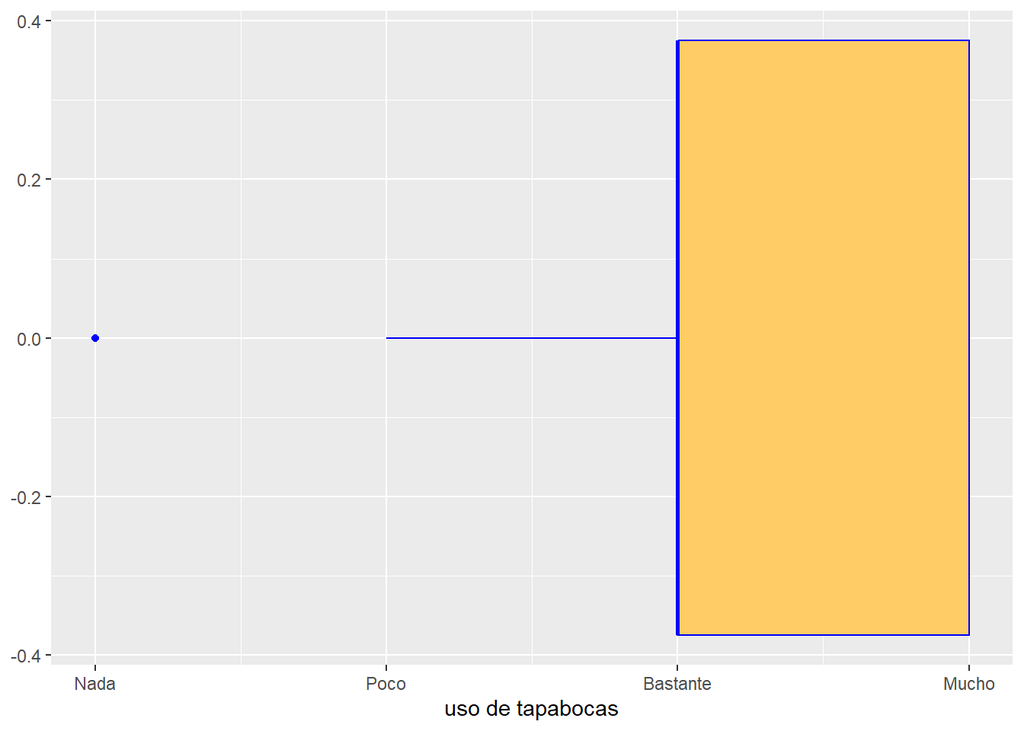

Uso de tapabocas

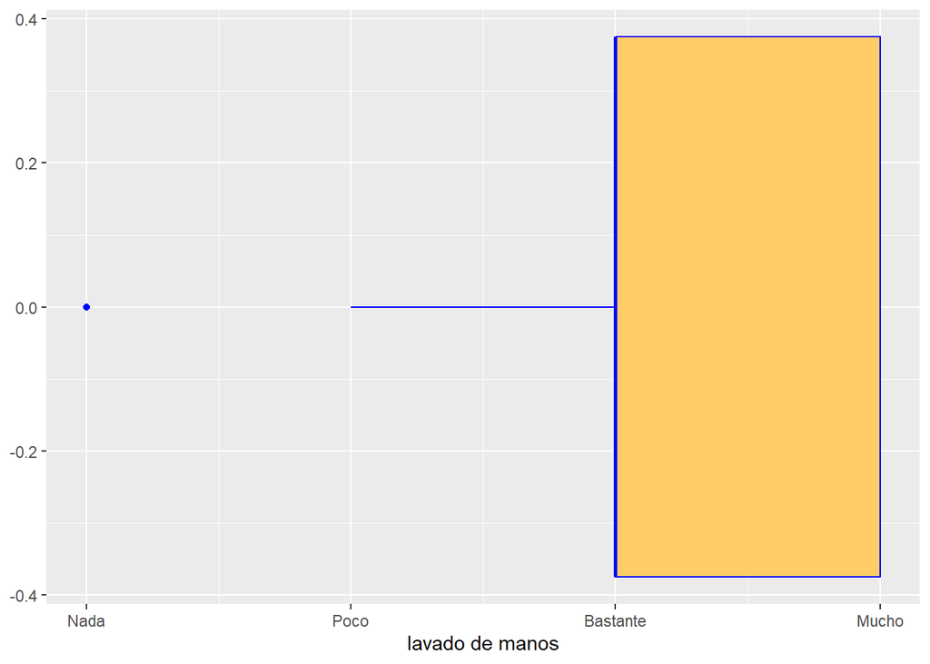

Lavado de manos

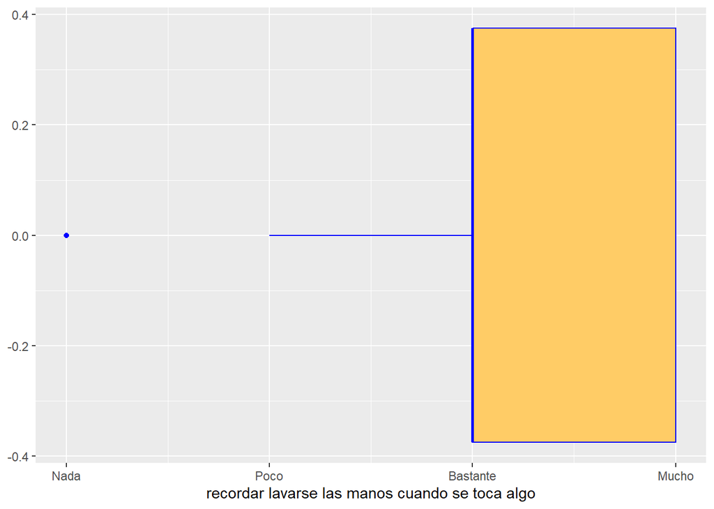

Acordarse de lavarse la manos cuando se toca algo

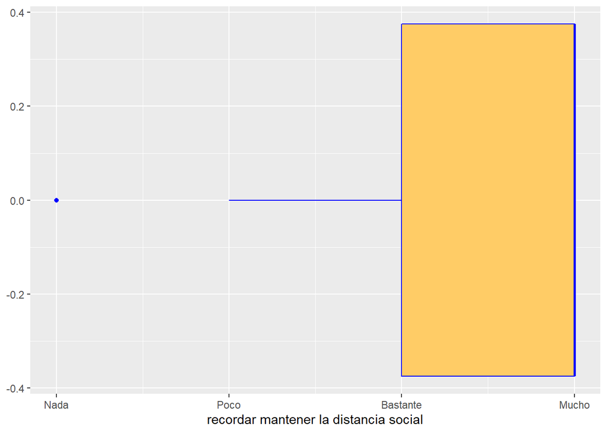

Recordar mantener la distancia social

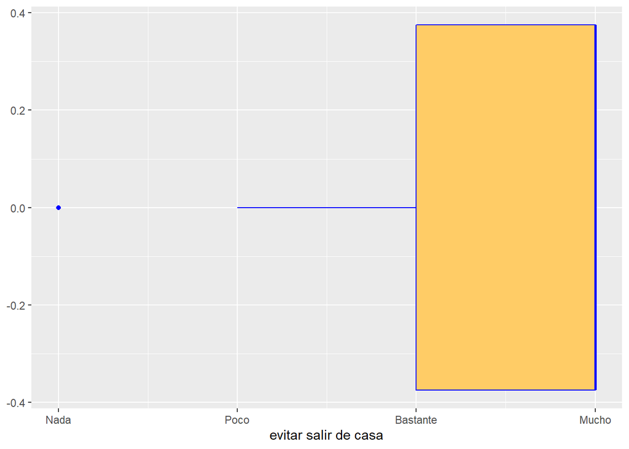

Evitar salir de la casa

r_pedir_cprev

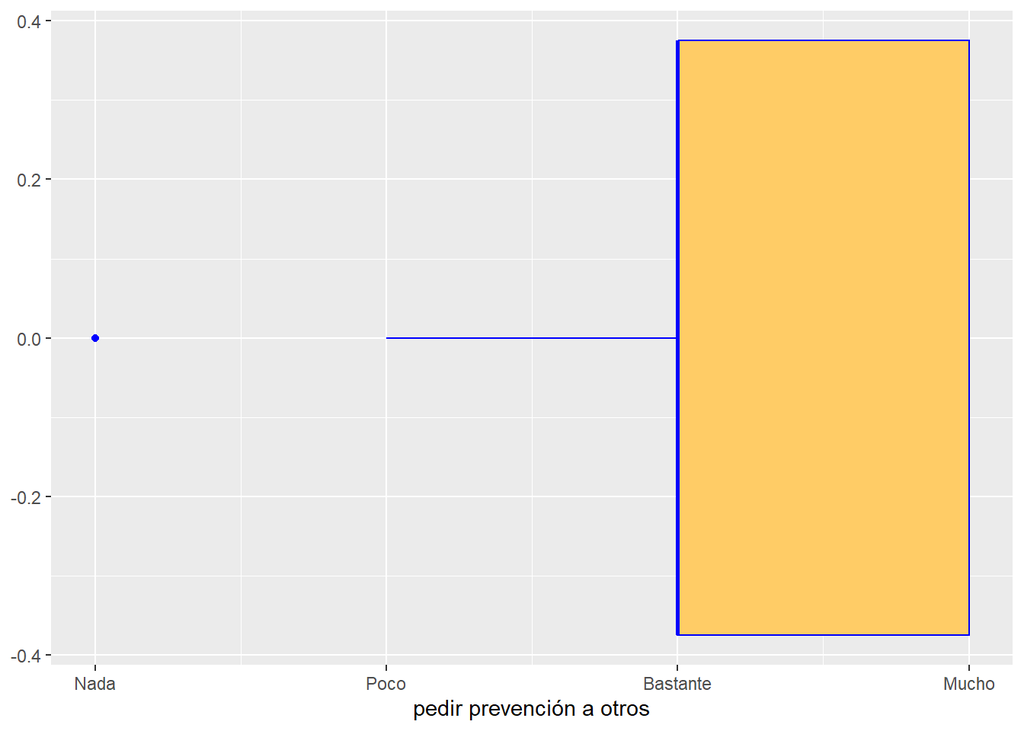

Pedir a los demás que adopten las conductas de prevención

In contrast, ‘usar guantes’ y ‘evitar tocarse la cara’ present different distributions consistent with interpreting them as less frequent behavior.

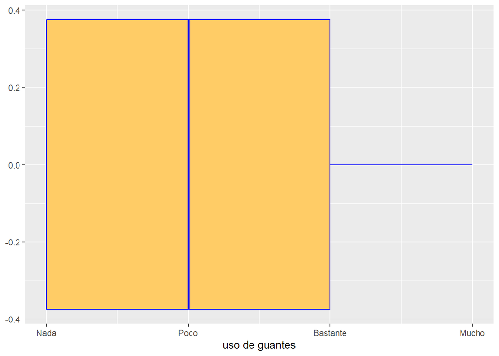

Usar guantes

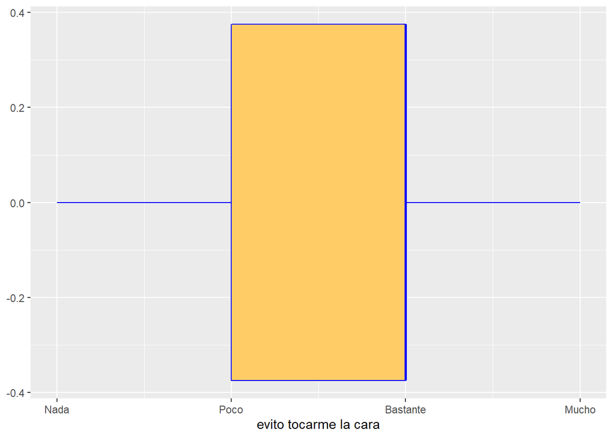

evito tocarme la cara

### Examples with demographics - gender

We can explore how the dependent measures (covid prevention behaviors) are divided by demographic categories, if it were of interest. As the descriptive summary showed, the sample is highly homogeneous in potential variables of interest as region, education level or occupation. But, in order to check some properties of the dependent measures, we can try to do an exploratory exercise using gender as the reference category.

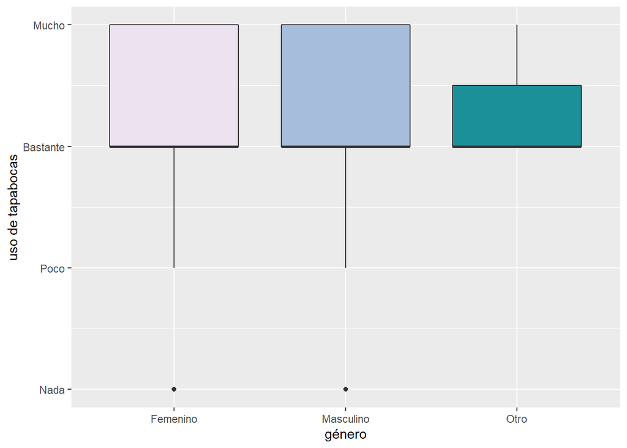

uso de tapabocas por género

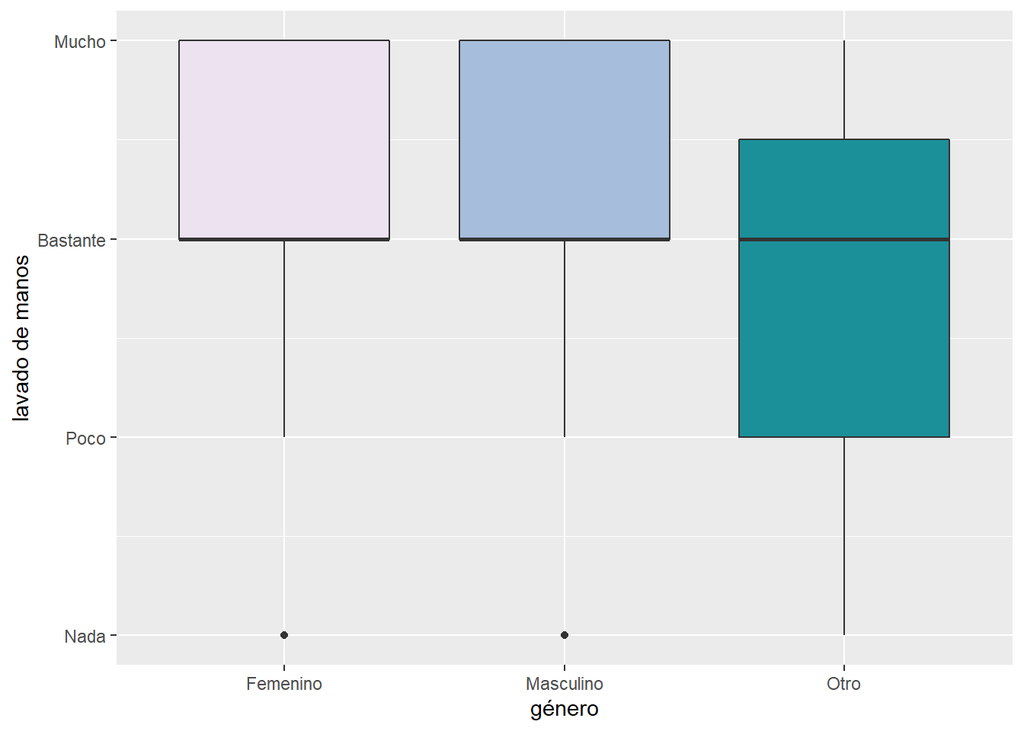

lavado de manos por género

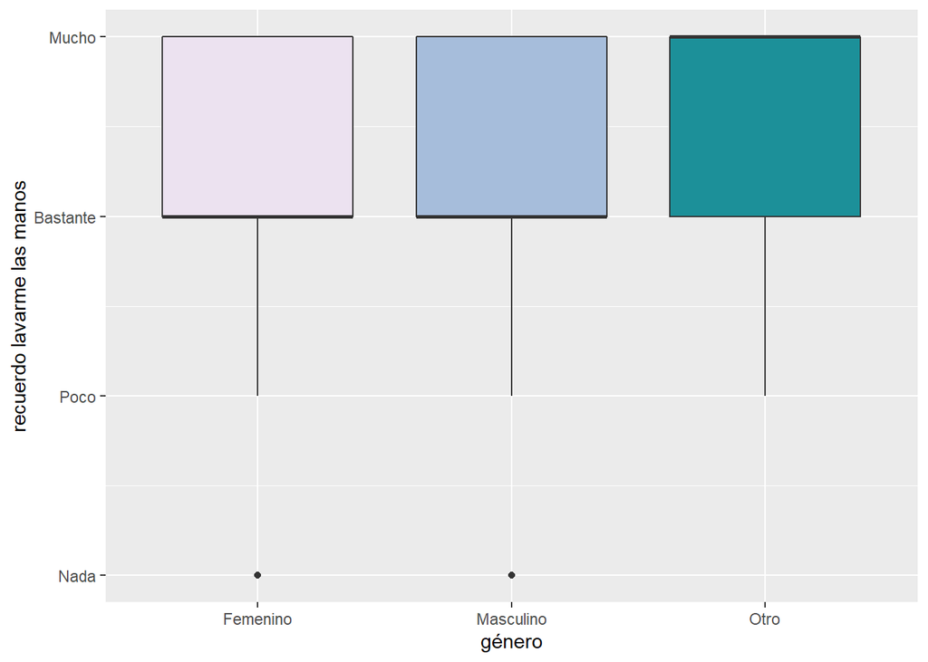

recordar lavarse las manos cuando toco algo por género

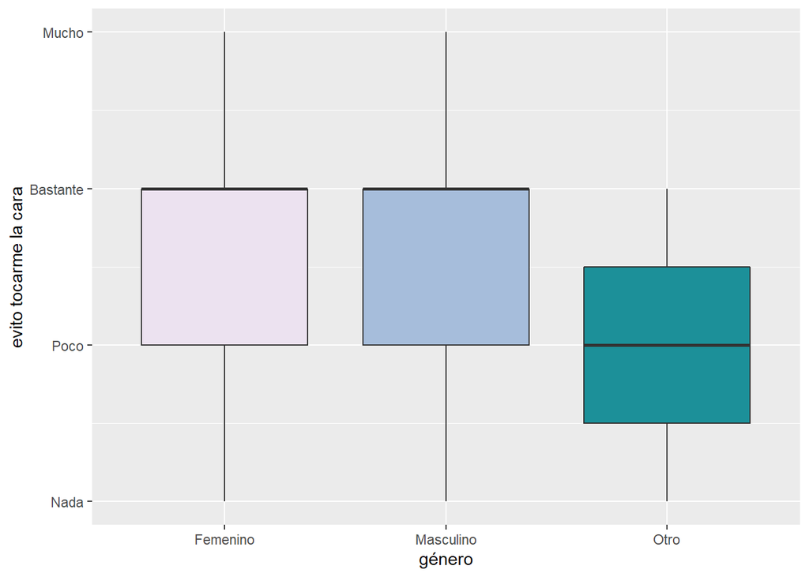

evitar tocarse la cara por género

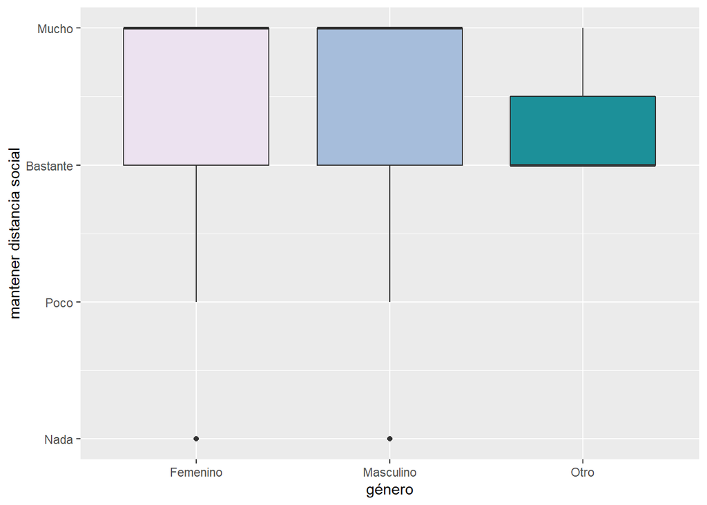

Recuerdo mantener la distancia social por género

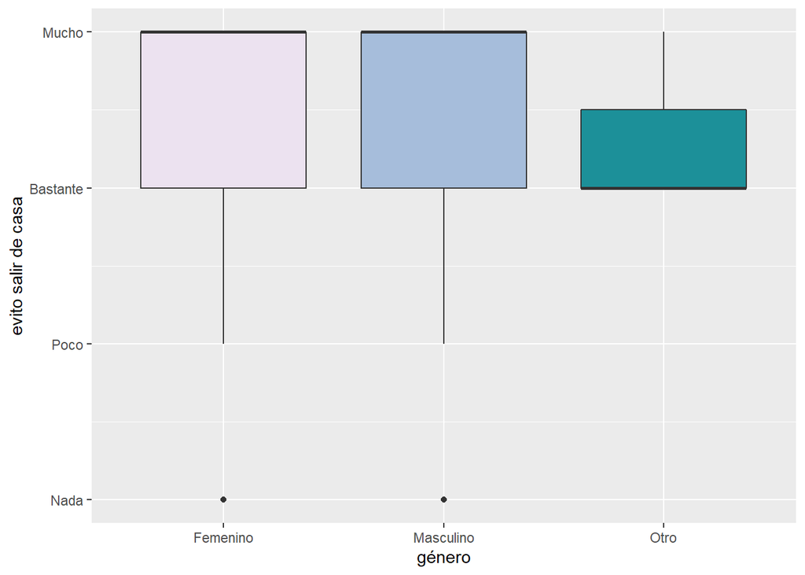

Evitar salir de casa por género

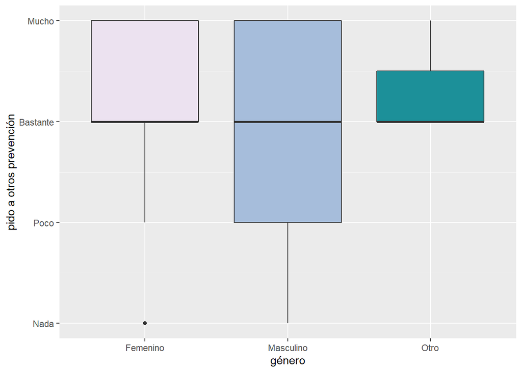

Pido a los demás que acojan las conductas de prevención por género

The previous figure shows that ‘pido a otros prevención’ seems to have a lower frequency compared with other dependent measures and it presents more variability in male compared with female.

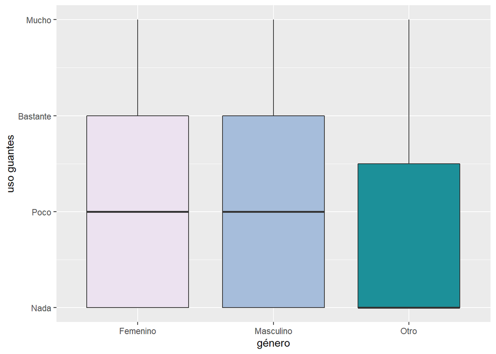

Uso guantes por género

Finally, ‘uso de guantes’ present a low frequency with no gender differences.

### Correlations between actions and intentions

In this section we will explore some potential interesting correlations between the variables measuring covid prevention behaviors and variables measuring the intention to adopt such kind of behaviors.

```r
actions <- select (ascofapsi, r_usotapabocas, r_usoguantes, r_lavadomanos, r_evitocara, r_acor_lavarmanos, r_acor_mantenerdistancia, r_salirdecasa, r_pedir_cprev)

intentions <- select (ascofapsi, i_usotapabocas, i_usotapabocas, i_usoguantes, i_lavadomanos, i_evitocara, i_acor_lavarmanos, i_acor_mantenerdistancia, i_salirdecasa, i_pedir_cprev)

actions_intentions <- select (ascofapsi, r_usotapabocas, r_usoguantes, r_lavadomanos, r_evitocara, r_acor_lavarmanos, r_acor_mantenerdistancia, r_salirdecasa, r_pedir_cprev, i_usotapabocas, i_usotapabocas, i_usoguantes, i_lavadomanos, i_evitocara, i_acor_lavarmanos, i_acor_mantenerdistancia, i_salirdecasa, i_pedir_cprev)
```

We start analyzing correlations between the variables measuring covid prevention behaviors using a matrix of correlations and a heatmap.

```r
cor_actions <- cor (actions)
kable(cor_actions)
```

|  | r_usotapabocas | r_usoguantes | r_lavadomanos | r_evitocara | r_acor_lavarmanos | r_acor_mantenerdistancia | r_salirdecasa | r_pedir_cprev |
| --- | --- | --- | --- | --- | --- | --- | --- | --- |
| r_usotapabocas | 1.0000000 | 0.4000916 | 0.3184776 | 0.3024738 | 0.2534073 | 0.3640708 | 0.0913167 | 0.2113488 |
| r_usoguantes | 0.4000916 | 1.0000000 | 0.2503110 | 0.2111618 | 0.1726485 | 0.1659534 | 0.0599041 | 0.1754335 |
| r_lavadomanos | 0.3184776 | 0.2503110 | 1.0000000 | 0.4748972 | 0.5032074 | 0.3427249 | 0.1310025 | 0.2901574 |
| r_evitocara | 0.3024738 | 0.2111618 | 0.4748972 | 1.0000000 | 0.4526469 | 0.3253618 | 0.1075052 | 0.2280510 |
| r_acor_lavarmanos | 0.2534073 | 0.1726485 | 0.5032074 | 0.4526469 | 1.0000000 | 0.4564139 | 0.2064474 | 0.3339629 |
| r_acor_mantenerdistancia | 0.3640708 | 0.1659534 | 0.3427249 | 0.3253618 | 0.4564139 | 1.0000000 | 0.2096794 | 0.3114433 |
| r_salirdecasa | 0.0913167 | 0.0599041 | 0.1310025 | 0.1075052 | 0.2064474 | 0.2096794 | 1.0000000 | 0.2568015 |
| r_pedir_cprev | 0.2113488 | 0.1754335 | 0.2901574 | 0.2280510 | 0.3339629 | 0.3114433 | 0.2568015 | 1.0000000 |

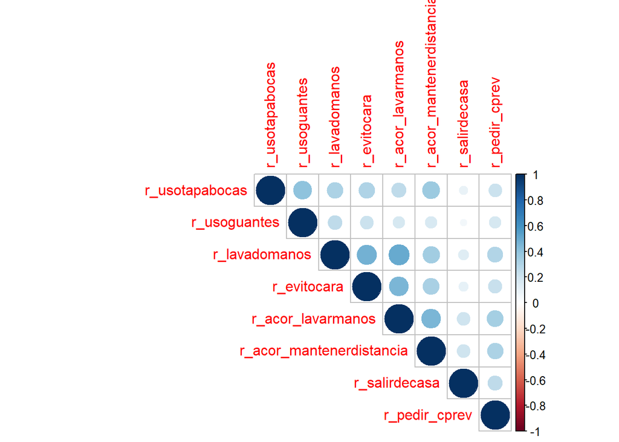

```r
corrplot(cor_actions, method = "circle", type = "upper")
```

The previous correlation matrix and heatmap show that while all of the correlations are possitive, they are weak. It is of special concern the weak correlation between ‘r_salirdecasa’ and ‘r_salirdecasa’ and all of the other variables measuring covid prevention behaviors.

A similar analysis for the correlations between the variables measuring the intention to adopt covid prevention behaviors.

```r
cor_intentions <- cor (intentions)
kable(cor_intentions)
```

|  | i_usotapabocas | i_usoguantes | i_lavadomanos | i_evitocara | i_acor_lavarmanos | i_acor_mantenerdistancia | i_salirdecasa | i_pedir_cprev |
| --- | --- | --- | --- | --- | --- | --- | --- | --- |
| i_usotapabocas | 1.0000000 | 0.2673590 | 0.5835619 | 0.4818013 | 0.6005471 | 0.6268522 | 0.3831578 | 0.3457886 |
| i_usoguantes | 0.2673590 | 1.0000000 | 0.2385230 | 0.2342086 | 0.2317594 | 0.2147360 | 0.2592768 | 0.3401238 |
| i_lavadomanos | 0.5835619 | 0.2385230 | 1.0000000 | 0.6179545 | 0.7130967 | 0.6158731 | 0.4313033 | 0.4105568 |
| i_evitocara | 0.4818013 | 0.2342086 | 0.6179545 | 1.0000000 | 0.6718192 | 0.5699261 | 0.3673687 | 0.3945126 |
| i_acor_lavarmanos | 0.6005471 | 0.2317594 | 0.7130967 | 0.6718192 | 1.0000000 | 0.6631685 | 0.4589937 | 0.4005793 |
| i_acor_mantenerdistancia | 0.6268522 | 0.2147360 | 0.6158731 | 0.5699261 | 0.6631685 | 1.0000000 | 0.4994175 | 0.4368639 |
| i_salirdecasa | 0.3831578 | 0.2592768 | 0.4313033 | 0.3673687 | 0.4589937 | 0.4994175 | 1.0000000 | 0.5022758 |
| i_pedir_cprev | 0.3457886 | 0.3401238 | 0.4105568 | 0.3945126 | 0.4005793 | 0.4368639 | 0.5022758 | 1.0000000 |

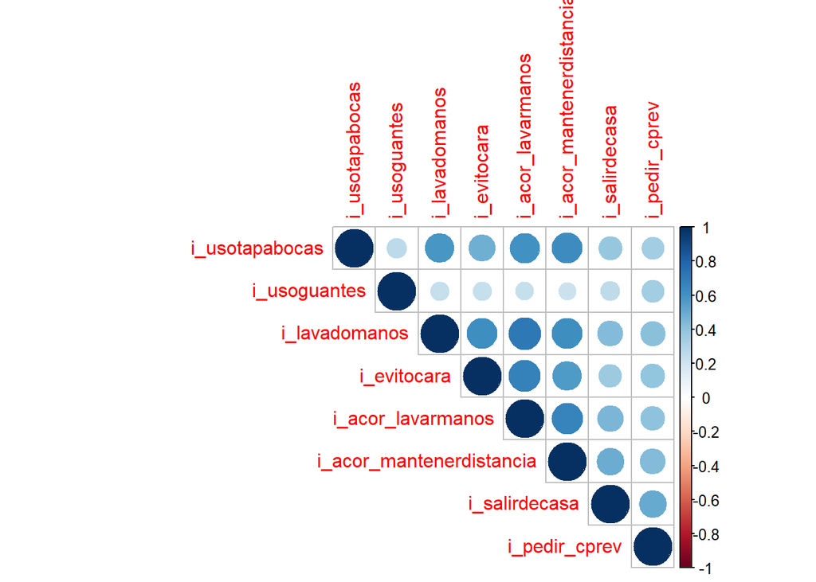

```r
corrplot(cor_intentions, method = "circle", type = "upper")
```

Again, all the correlations are positive but, in contrast with the correlations between actions, the correlations between intentions are stronger. ‘i_usoguantes’ has the lower correlations with the other variables measuring intentions to adopt covid prevention behaviors. Then, it may be interesting asking about why intentions to act correlate stronger than the actions themselves.

```r
cor_actions_intentions <- cor (actions_intentions)
kable(cor_actions_intentions)
```

|  | r_usotapabocas | r_usoguantes | r_lavadomanos | r_evitocara | r_acor_lavarmanos | r_acor_mantenerdistancia | r_salirdecasa | r_pedir_cprev | i_usotapabocas | i_usoguantes | i_lavadomanos | i_evitocara | i_acor_lavarmanos | i_acor_mantenerdistancia | i_salirdecasa | i_pedir_cprev |
| --- | --- | --- | --- | --- | --- | --- | --- | --- | --- | --- | --- | --- | --- | --- | --- | --- |
| r_usotapabocas | 1.0000000 | 0.4000916 | 0.3184776 | 0.3024738 | 0.2534073 | 0.3640708 | 0.0913167 | 0.2113488 | 0.4473592 | 0.1573203 | 0.2229943 | 0.2164111 | 0.2478214 | 0.2609489 | 0.1230917 | 0.1603819 |
| r_usoguantes | 0.4000916 | 1.0000000 | 0.2503110 | 0.2111618 | 0.1726485 | 0.1659534 | 0.0599041 | 0.1754335 | 0.2121905 | 0.5479721 | 0.1435600 | 0.1342869 | 0.1221012 | 0.0987303 | 0.1193994 | 0.1460884 |
| r_lavadomanos | 0.3184776 | 0.2503110 | 1.0000000 | 0.4748972 | 0.5032074 | 0.3427249 | 0.1310025 | 0.2901574 | 0.2515919 | 0.1484956 | 0.4386579 | 0.3297464 | 0.3703233 | 0.2873314 | 0.2404305 | 0.1884747 |
| r_evitocara | 0.3024738 | 0.2111618 | 0.4748972 | 1.0000000 | 0.4526469 | 0.3253618 | 0.1075052 | 0.2280510 | 0.1742266 | 0.1027834 | 0.2741087 | 0.4443487 | 0.2965871 | 0.2051543 | 0.1570071 | 0.1549172 |
| r_acor_lavarmanos | 0.2534073 | 0.1726485 | 0.5032074 | 0.4526469 | 1.0000000 | 0.4564139 | 0.2064474 | 0.3339629 | 0.2743571 | 0.0873425 | 0.3942034 | 0.3660464 | 0.5113764 | 0.3019167 | 0.2142088 | 0.2083303 |
| r_acor_mantenerdistancia | 0.3640708 | 0.1659534 | 0.3427249 | 0.3253618 | 0.4564139 | 1.0000000 | 0.2096794 | 0.3114433 | 0.3232463 | 0.0655243 | 0.3061256 | 0.2943862 | 0.3514778 | 0.4794909 | 0.2398383 | 0.2377949 |
| r_salirdecasa | 0.0913167 | 0.0599041 | 0.1310025 | 0.1075052 | 0.2064474 | 0.2096794 | 1.0000000 | 0.2568015 | 0.1688852 | 0.1012110 | 0.2034605 | 0.1619299 | 0.1917934 | 0.2284958 | 0.3628792 | 0.1923172 |
| r_pedir_cprev | 0.2113488 | 0.1754335 | 0.2901574 | 0.2280510 | 0.3339629 | 0.3114433 | 0.2568015 | 1.0000000 | 0.2011186 | 0.1670706 | 0.2300259 | 0.2222768 | 0.2455266 | 0.2613626 | 0.2864111 | 0.5248766 |
| i_usotapabocas | 0.4473592 | 0.2121905 | 0.2515919 | 0.1742266 | 0.2743571 | 0.3232463 | 0.1688852 | 0.2011186 | 1.0000000 | 0.2673590 | 0.5835619 | 0.4818013 | 0.6005471 | 0.6268522 | 0.3831578 | 0.3457886 |
| i_usoguantes | 0.1573203 | 0.5479721 | 0.1484956 | 0.1027834 | 0.0873425 | 0.0655243 | 0.1012110 | 0.1670706 | 0.2673590 | 1.0000000 | 0.2385230 | 0.2342086 | 0.2317594 | 0.2147360 | 0.2592768 | 0.3401238 |
| i_lavadomanos | 0.2229943 | 0.1435600 | 0.4386579 | 0.2741087 | 0.3942034 | 0.3061256 | 0.2034605 | 0.2300259 | 0.5835619 | 0.2385230 | 1.0000000 | 0.6179545 | 0.7130967 | 0.6158731 | 0.4313033 | 0.4105568 |
| i_evitocara | 0.2164111 | 0.1342869 | 0.3297464 | 0.4443487 | 0.3660464 | 0.2943862 | 0.1619299 | 0.2222768 | 0.4818013 | 0.2342086 | 0.6179545 | 1.0000000 | 0.6718192 | 0.5699261 | 0.3673687 | 0.3945126 |
| i_acor_lavarmanos | 0.2478214 | 0.1221012 | 0.3703233 | 0.2965871 | 0.5113764 | 0.3514778 | 0.1917934 | 0.2455266 | 0.6005471 | 0.2317594 | 0.7130967 | 0.6718192 | 1.0000000 | 0.6631685 | 0.4589937 | 0.4005793 |
| i_acor_mantenerdistancia | 0.2609489 | 0.0987303 | 0.2873314 | 0.2051543 | 0.3019167 | 0.4794909 | 0.2284958 | 0.2613626 | 0.6268522 | 0.2147360 | 0.6158731 | 0.5699261 | 0.6631685 | 1.0000000 | 0.4994175 | 0.4368639 |
| i_salirdecasa | 0.1230917 | 0.1193994 | 0.2404305 | 0.1570071 | 0.2142088 | 0.2398383 | 0.3628792 | 0.2864111 | 0.3831578 | 0.2592768 | 0.4313033 | 0.3673687 | 0.4589937 | 0.4994175 | 1.0000000 | 0.5022758 |
| i_pedir_cprev | 0.1603819 | 0.1460884 | 0.1884747 | 0.1549172 | 0.2083303 | 0.2377949 | 0.1923172 | 0.5248766 | 0.3457886 | 0.3401238 | 0.4105568 | 0.3945126 | 0.4005793 | 0.4368639 | 0.5022758 | 1.0000000 |

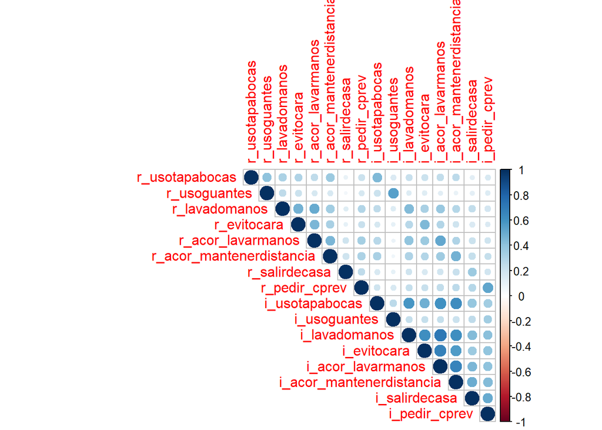

```r
corrplot(cor_actions_intentions, method = "circle", type = "upper")
```

As we expected, all the correlations are positive. In general, each intention has a medium correlation with their corresponding behavior, with the exception of ‘i_salirdecasa’ and ‘r_salirdecasa’ (r=0.36). This show that possibly ‘intentions’ are not the most useful construct when trying to design interventions over covid prevention behaviors or when we are trying to identify a proxy variable for covid prevention behaviors.

### Correlations between actions and self-efficacy

In this section we will explore some potential interesting correlations between the variables measuring covid prevention behaviors and variables measuring the perceived self-efficacy to adopt such kind of behaviors.

```r
self_efficacy <- select (ascofapsi, cpz_usotapabocas, cpz_usoguantes, cpz_lavadomanos, cpz_evitocara, cpz_acor_lavarmanos, cpz_acor_mantenerdistancia, cpz_salirdecasa, cpz_pedir_cprev)

actions_selfefficacy <- select (ascofapsi, r_usotapabocas, r_usoguantes, r_lavadomanos, r_evitocara, r_acor_lavarmanos, r_acor_mantenerdistancia, r_salirdecasa, r_pedir_cprev,  cpz_usotapabocas, cpz_usoguantes, cpz_lavadomanos, cpz_evitocara, cpz_acor_lavarmanos, cpz_acor_mantenerdistancia, cpz_salirdecasa, cpz_pedir_cprev)
```

First, the analysis of the correlations between variables measuring perceived self-efficacy

```r
cor_selfefficacy <- cor (self_efficacy)
kable(cor_selfefficacy)
```

|  | cpz_usotapabocas | cpz_usoguantes | cpz_lavadomanos | cpz_evitocara | cpz_acor_lavarmanos | cpz_acor_mantenerdistancia | cpz_salirdecasa | cpz_pedir_cprev |
| --- | --- | --- | --- | --- | --- | --- | --- | --- |
| cpz_usotapabocas | 1.0000000 | 0.3664275 | 0.4995963 | 0.3976181 | 0.4546540 | 0.5209209 | 0.3253661 | 0.3360739 |
| cpz_usoguantes | 0.3664275 | 1.0000000 | 0.3676890 | 0.2873147 | 0.2807132 | 0.2315393 | 0.2412606 | 0.2425388 |
| cpz_lavadomanos | 0.4995963 | 0.3676890 | 1.0000000 | 0.5275690 | 0.5985858 | 0.5094266 | 0.3070795 | 0.3073407 |
| cpz_evitocara | 0.3976181 | 0.2873147 | 0.5275690 | 1.0000000 | 0.5332988 | 0.4396185 | 0.2730285 | 0.3727980 |
| cpz_acor_lavarmanos | 0.4546540 | 0.2807132 | 0.5985858 | 0.5332988 | 1.0000000 | 0.5570156 | 0.3064263 | 0.3923877 |
| cpz_acor_mantenerdistancia | 0.5209209 | 0.2315393 | 0.5094266 | 0.4396185 | 0.5570156 | 1.0000000 | 0.3906660 | 0.4051054 |
| cpz_salirdecasa | 0.3253661 | 0.2412606 | 0.3070795 | 0.2730285 | 0.3064263 | 0.3906660 | 1.0000000 | 0.4139529 |
| cpz_pedir_cprev | 0.3360739 | 0.2425388 | 0.3073407 | 0.3727980 | 0.3923877 | 0.4051054 | 0.4139529 | 1.0000000 |

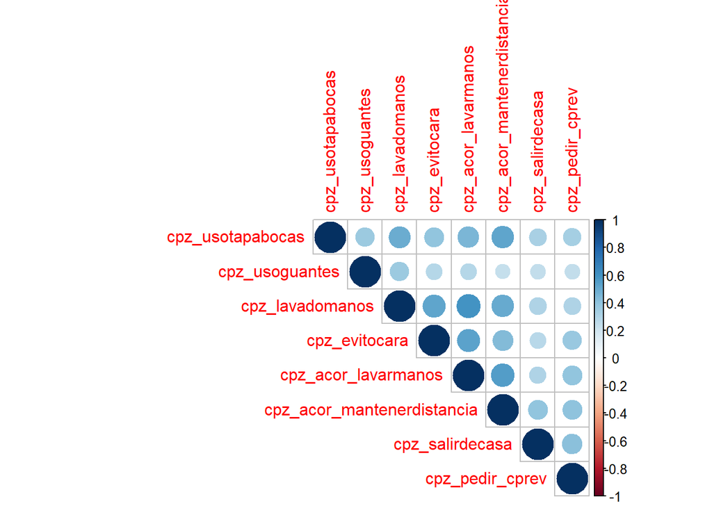

```r
corrplot(cor_selfefficacy, method = "circle", type = "upper")
```

In general, again, all the correlations are positive, while they are less strong that the correlations between intentions.

```r
cor_actions_selfefficacy <- cor (actions_selfefficacy)
kable(cor_actions_selfefficacy)
```

|  | r_usotapabocas | r_usoguantes | r_lavadomanos | r_evitocara | r_acor_lavarmanos | r_acor_mantenerdistancia | r_salirdecasa | r_pedir_cprev | cpz_usotapabocas | cpz_usoguantes | cpz_lavadomanos | cpz_evitocara | cpz_acor_lavarmanos | cpz_acor_mantenerdistancia | cpz_salirdecasa | cpz_pedir_cprev |
| --- | --- | --- | --- | --- | --- | --- | --- | --- | --- | --- | --- | --- | --- | --- | --- | --- |
| r_usotapabocas | 1.0000000 | 0.4000916 | 0.3184776 | 0.3024738 | 0.2534073 | 0.3640708 | 0.0913167 | 0.2113488 | 0.3857909 | 0.1410562 | 0.2245320 | 0.2217362 | 0.2397792 | 0.3206466 | 0.0976735 | 0.1617383 |
| r_usoguantes | 0.4000916 | 1.0000000 | 0.2503110 | 0.2111618 | 0.1726485 | 0.1659534 | 0.0599041 | 0.1754335 | 0.1620572 | 0.5012282 | 0.1299607 | 0.1730663 | 0.1517585 | 0.1176076 | 0.0933153 | 0.1333313 |
| r_lavadomanos | 0.3184776 | 0.2503110 | 1.0000000 | 0.4748972 | 0.5032074 | 0.3427249 | 0.1310025 | 0.2901574 | 0.3073935 | 0.2222539 | 0.5863367 | 0.3552394 | 0.4090633 | 0.3150129 | 0.2163412 | 0.1863926 |
| r_evitocara | 0.3024738 | 0.2111618 | 0.4748972 | 1.0000000 | 0.4526469 | 0.3253618 | 0.1075052 | 0.2280510 | 0.2277613 | 0.1412930 | 0.3382895 | 0.6123330 | 0.3526617 | 0.2628915 | 0.1526334 | 0.2000496 |
| r_acor_lavarmanos | 0.2534073 | 0.1726485 | 0.5032074 | 0.4526469 | 1.0000000 | 0.4564139 | 0.2064474 | 0.3339629 | 0.3344238 | 0.1621385 | 0.4154024 | 0.3881733 | 0.6614927 | 0.3545043 | 0.2183492 | 0.2841067 |
| r_acor_mantenerdistancia | 0.3640708 | 0.1659534 | 0.3427249 | 0.3253618 | 0.4564139 | 1.0000000 | 0.2096794 | 0.3114433 | 0.4209547 | 0.1344707 | 0.3134390 | 0.2869604 | 0.3777924 | 0.6198272 | 0.2466715 | 0.2791816 |
| r_salirdecasa | 0.0913167 | 0.0599041 | 0.1310025 | 0.1075052 | 0.2064474 | 0.2096794 | 1.0000000 | 0.2568015 | 0.1858525 | 0.1073886 | 0.2070593 | 0.1342946 | 0.2330170 | 0.1961560 | 0.4571286 | 0.2116522 |
| r_pedir_cprev | 0.2113488 | 0.1754335 | 0.2901574 | 0.2280510 | 0.3339629 | 0.3114433 | 0.2568015 | 1.0000000 | 0.2396801 | 0.1682987 | 0.2262875 | 0.2390234 | 0.2987201 | 0.2943070 | 0.2663570 | 0.6353032 |
| cpz_usotapabocas | 0.3857909 | 0.1620572 | 0.3073935 | 0.2277613 | 0.3344238 | 0.4209547 | 0.1858525 | 0.2396801 | 1.0000000 | 0.3664275 | 0.4995963 | 0.3976181 | 0.4546540 | 0.5209209 | 0.3253661 | 0.3360739 |
| cpz_usoguantes | 0.1410562 | 0.5012282 | 0.2222539 | 0.1412930 | 0.1621385 | 0.1344707 | 0.1073886 | 0.1682987 | 0.3664275 | 1.0000000 | 0.3676890 | 0.2873147 | 0.2807132 | 0.2315393 | 0.2412606 | 0.2425388 |
| cpz_lavadomanos | 0.2245320 | 0.1299607 | 0.5863367 | 0.3382895 | 0.4154024 | 0.3134390 | 0.2070593 | 0.2262875 | 0.4995963 | 0.3676890 | 1.0000000 | 0.5275690 | 0.5985858 | 0.5094266 | 0.3070795 | 0.3073407 |
| cpz_evitocara | 0.2217362 | 0.1730663 | 0.3552394 | 0.6123330 | 0.3881733 | 0.2869604 | 0.1342946 | 0.2390234 | 0.3976181 | 0.2873147 | 0.5275690 | 1.0000000 | 0.5332988 | 0.4396185 | 0.2730285 | 0.3727980 |
| cpz_acor_lavarmanos | 0.2397792 | 0.1517585 | 0.4090633 | 0.3526617 | 0.6614927 | 0.3777924 | 0.2330170 | 0.2987201 | 0.4546540 | 0.2807132 | 0.5985858 | 0.5332988 | 1.0000000 | 0.5570156 | 0.3064263 | 0.3923877 |
| cpz_acor_mantenerdistancia | 0.3206466 | 0.1176076 | 0.3150129 | 0.2628915 | 0.3545043 | 0.6198272 | 0.1961560 | 0.2943070 | 0.5209209 | 0.2315393 | 0.5094266 | 0.4396185 | 0.5570156 | 1.0000000 | 0.3906660 | 0.4051054 |
| cpz_salirdecasa | 0.0976735 | 0.0933153 | 0.2163412 | 0.1526334 | 0.2183492 | 0.2466715 | 0.4571286 | 0.2663570 | 0.3253661 | 0.2412606 | 0.3070795 | 0.2730285 | 0.3064263 | 0.3906660 | 1.0000000 | 0.4139529 |
| cpz_pedir_cprev | 0.1617383 | 0.1333313 | 0.1863926 | 0.2000496 | 0.2841067 | 0.2791816 | 0.2116522 | 0.6353032 | 0.3360739 | 0.2425388 | 0.3073407 | 0.3727980 | 0.3923877 | 0.4051054 | 0.4139529 | 1.0000000 |

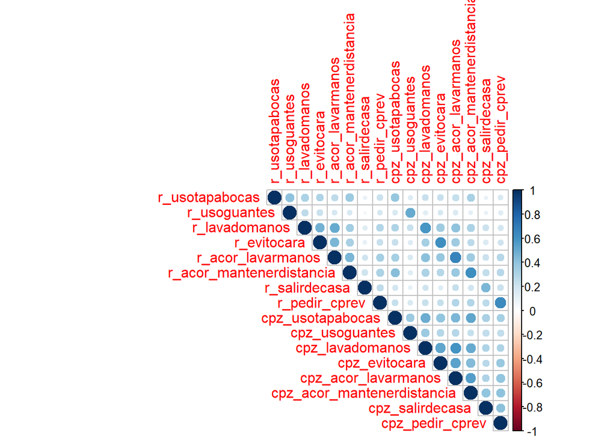

```r
corrplot(cor_actions_selfefficacy, method = "circle", type = "upper")
```

In general, there are medium correlations between variables measuring perceived self-efficacy to adopt covid prevention behaviors and variables measuring the adoption of such kind of behaviors. Then, it is interesting to ask about a comparison between the effect of self-efficacy and intention over the adoption of covid prevention behaviors. But, the correlation analysis seems to advert that neither intentions and self-efficacy are good predictors of covid prevention behaviors, which may be useful, for example, in order to evaluate initiatives that promote prevention behaviors appealing to these constructs.